# Analyse de sensibilité d’un modèle de socio-écosystème marin

### 5.2.2 A quel point nous serions nous trompés dans le calcul des indices si nous n’avions pas mis de dépendance entre les paramètres d’entrée ? Et si nous avions utilisé une méthode d’estimation ne prenant pas en compte la dépendance ?

Tout d’abord, précisons que, sur les graphiques qui suivent la légende “estimationIndice” indique pour quel jeu de données et de quelle manière les indices ont été calculé. On précise aussi que le calcul des indices de Sobol-MDA requiert la construction d’un random forest tandis que le calcul des indices de Sobol totaux se fait directement sur nos données. Ainsi :

- S-MDA dep signifie que nous avons calculé les indices de Sobol-MDA pour des paramètres avec une hypothèse de dépendance (corrélation de -0.3 entre survie et dérive et corrélation de -0.5 entre survie et mortalité)
- S-MDA indep signifie que nous avons calulé les indices de Sobol-MDA pour des paramètres avec une hypothèse d’indépendance.
- ST dep signifie que nous avons calculé les indices de Sobol totaux pour des paramètres avec une hypothèse de dépendance.
- ST dep signifie que nous avons calculé les indices de Sobol totaux pour des paramètres avec une hypothèse d’indépendance.

#### 5.2.2.1 biomasse

Globalement, on remarque que l’hypothèse de dépendance que nous avons mise ne fait pas varier significativement la valeur des indices, de même que la méthode de calul utiliser. Néanmoins, on remarque que les indices qui varient le plus en fonction de l’hypothèse et des méthodes sont ceux des paramètres sur lesquels on a mis une corrélation. En somme, l’utilisation d’un méthode classique de calcul des indices de Sobol totaux et/ou une hypothèse d’indépendance sur les paramètres n’aurait pas changé les conclusions de notre analyse de sensibilité dans ce cas précis.

##### 5.2.2.1.1 annee 1

Pour la mortalité et la survie, on voit des différences notables entre S-MDA dep et ST Indep. Néanmoins, malgré cette différence, l’indice de la survie reste plus grand que celui de la mortalité dans les deux cas.

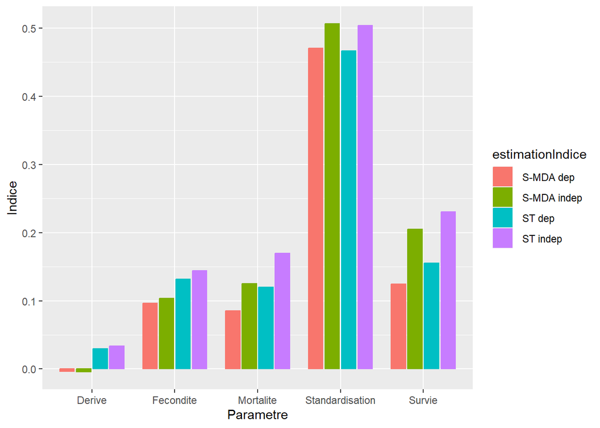

##### 5.2.2.1.2 annee 2

On note quelques différences notables entre les valeurs mais celles-ci ne modifient pas le classement des paramètres par ordre d’influence.

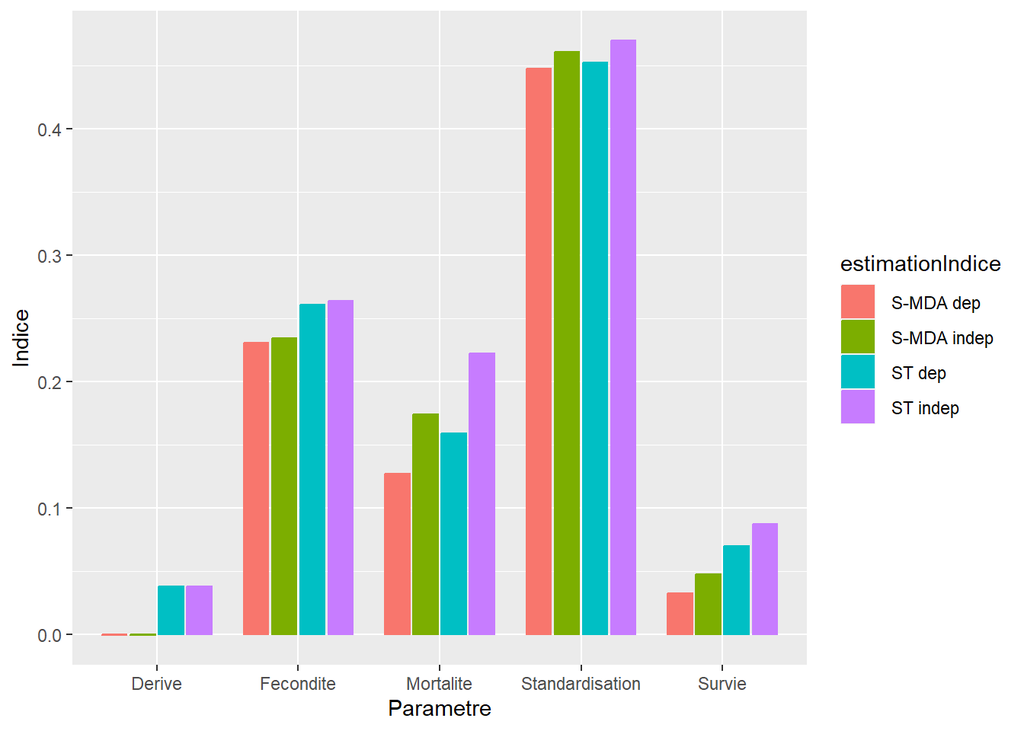

##### 5.2.2.1.3 année 3

Pour les paramètres non-corrélés, les indices sont très rapprochés, ils sont plus éloignés pour les paramètres corrélés.

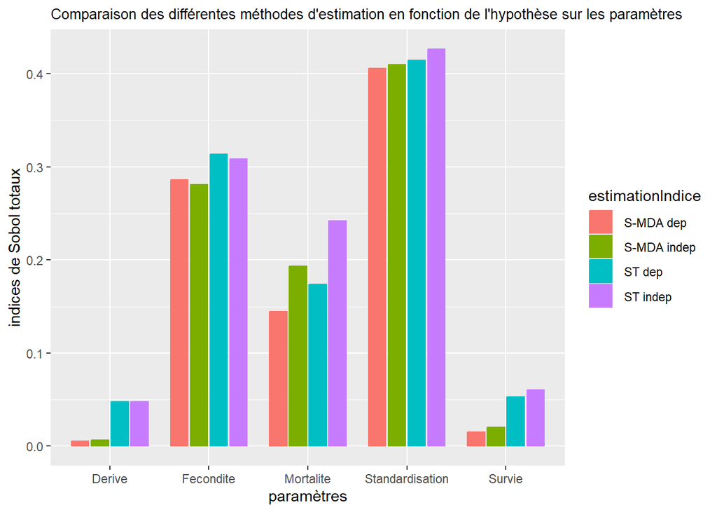

##### 5.2.2.1.4 année 4

Pour les paramètres non-corrélés, les indices sont très rapprochés, ils sont plus éloignés pour les paramètres corrélés.

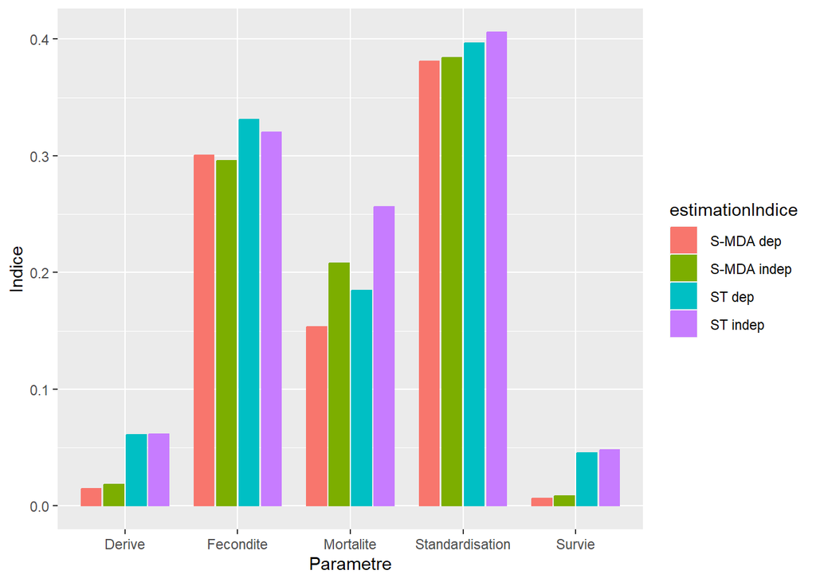

#### 5.2.2.2 biomasse féconde

Globalement, on remarque que l’hypothèse de dépendance que nous avons mise ne fait pas varier significativement la valeur des indices, de même que la méthode de calul utiliser. Néanmoins, on remarque que les indices qui varient le plus en fonction de l’hypothèse et des méthodes sont ceux des paramètres sur lesquels on a mis une corrélation. En somme, l’utilisation d’un méthode classique de calcul des indices de Sobol totaux et/ou une hypothèse d’indépendance sur les paramètres n’aurait pas changé les conclusions de notre analyse de sensibilité dans ce cas précis.

##### 5.2.2.2.1 annee 1

On note peu de différences entre les indices, le choix de la méthode et de l’hypothèse de dépendance ou indépendance n’aurait pas changé les conclusions de notre analyse de sensibilité.

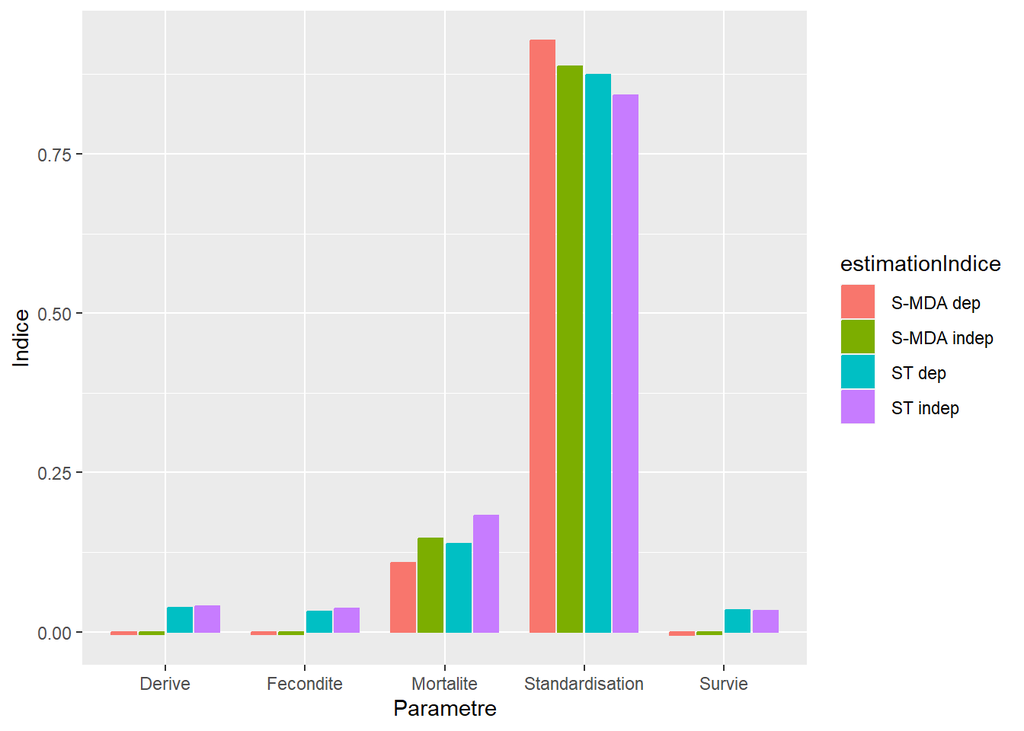

##### 5.2.2.2.2 annee 2

On note peu de différences entre les indices, le choix de la méthode et de l’hypothèse de dépendance ou indépendance n’aurait pas changé les conclusions de notre analyse de sensibilité.

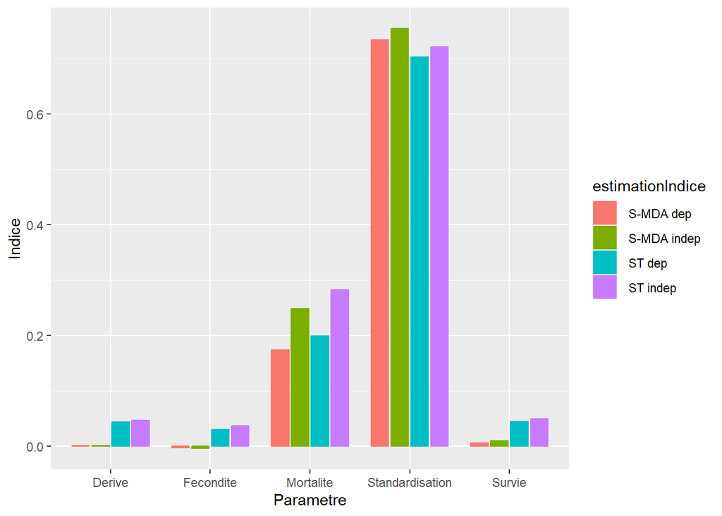

##### 5.2.2.2.3 année 3

On note peu de différences entre les indices, le choix de la méthode et de l’hypothèse de dépendance ou indépendance, n’aurait pas changé les conclusions de notre analyse de sensibilité.

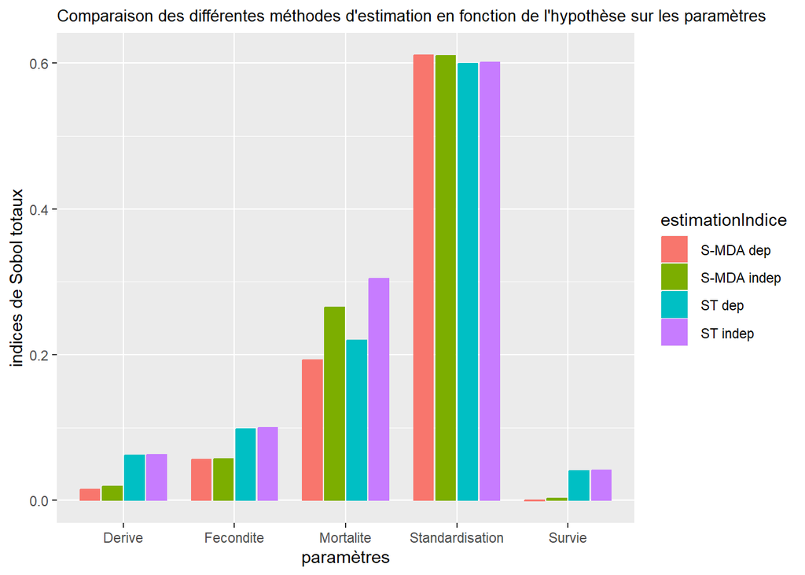

##### 5.2.2.2.4 année 4

On note peu de différences entre les indices, le choix de la méthode et de l’hypothèse de dépendance ou indépendance, n’aurait pas changé les conclusions de notre analyse de sensibilité.

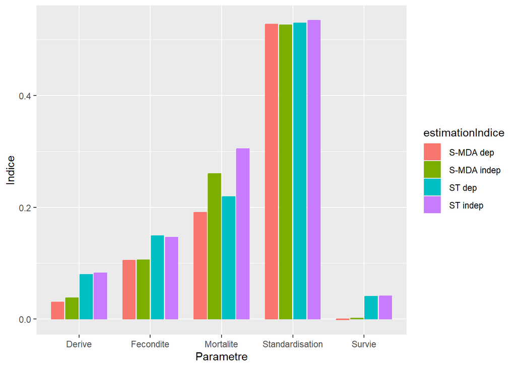

#### 5.2.2.3 captures

##### 5.2.2.3.1 annee 1

On remarque que quelque soit la méthode de calcul utilisée, pour les mêmes hypothèses sur les paramètres les indices sont presque identiques. En revanche, l’hypothèse sur la dépendance (oui ou non) fait varier les valeurs des indices corrélés.

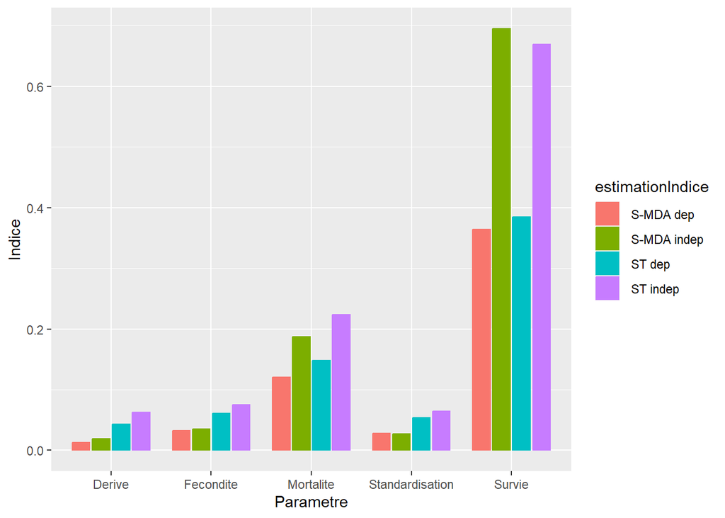

##### 5.2.2.3.2 annee 2

On remarque que quelque soit la méthode de calcul utilisée, pour les mêmes hypothèses sur les paramètres les indices sont presque identiques. En revanche, l’hypothèse sur la dépendance (oui ou non) fait varier les valeurs des indices corrélés.

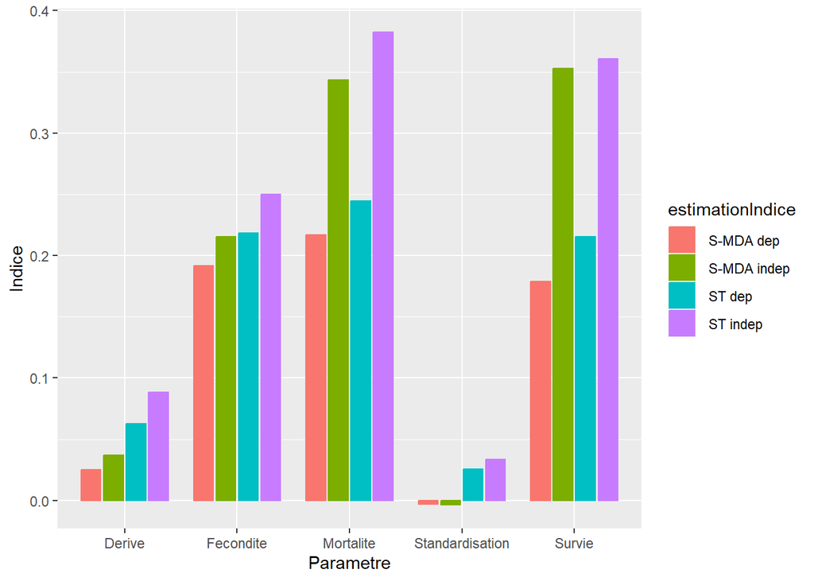

##### 5.2.2.3.3 annee 3

On remarque que quelque soit la méthode de calcul utilisée, pour les mêmes hypothèses sur les paramètres les indices sont presque identiques. En revanche, l’hypothèse sur la dépendance (oui ou non) fait varier les valeurs des indices corrélés.

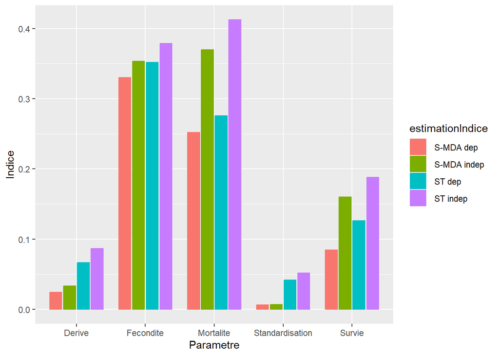

##### 5.2.2.3.4 annee 4

On remarque que quelque soit la méthode de calcul utilisée, pour les mêmes hypothèses sur les paramètres les indices sont presque identiques. En revanche, l’hypothèse sur la dépendance (oui ou non) fait varier les valeurs des indices corrélés.

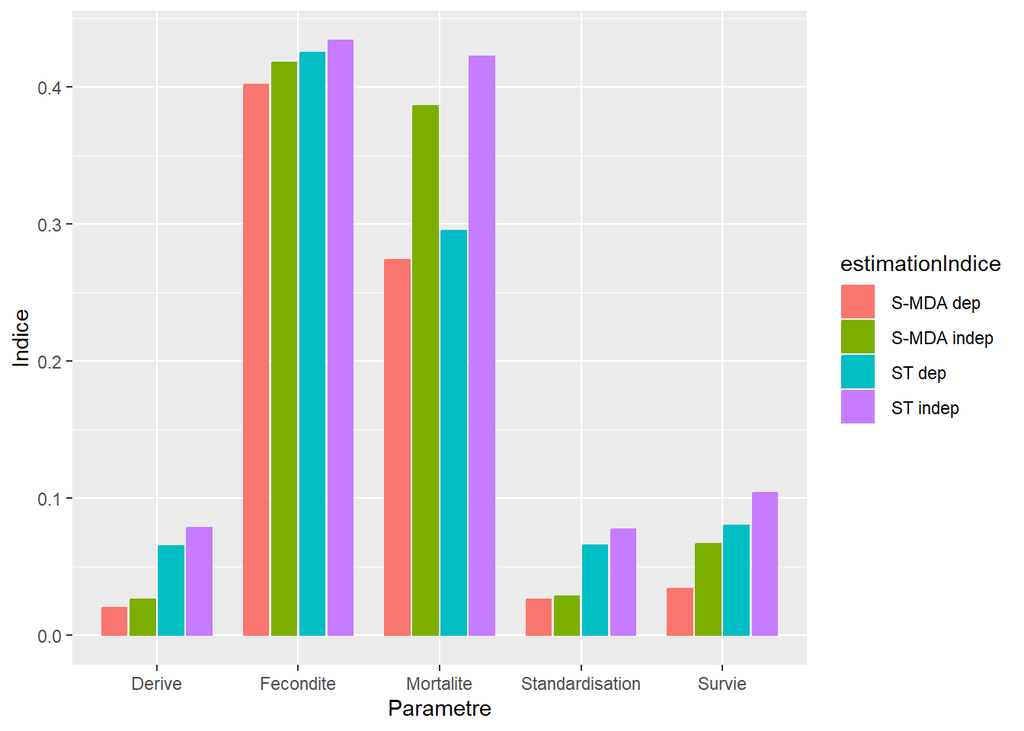

### 5.2.3 Quel est l’effet de la corrélation entre les paramètres d’entrée sur la valeur des indices de sensibilité ?

On remarque que les indices de Sobol-MDA des paramètres corrélés diminue significativement lorsque la corrélation augmente. Dans certains cas, l’augmentation de la corrélation entre les paramètres modifie le classement par ordre d’influence des paramètres.

#### 5.2.3.1 biomasse

##### 5.2.3.1.1 année 1

Les indices des paramètres non corrélés ont tendance à stagner tandis que ceux de paramètres corrélés diminuent lorsque la corrélation augmente. Le classement des paramètres change en fonction des valeurs de corrélation.

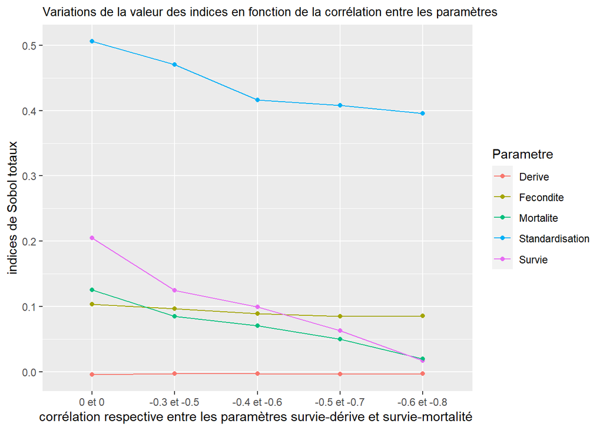

##### 5.2.3.1.2 annee 2

Les indices des paramètres non corrélés ont tendance à stagner tandis que ceux de paramètres corrélés diminuent lorsque la corrélation augmente. Le classement des paramètres ne change pas en fonction des valeurs de corrélation.

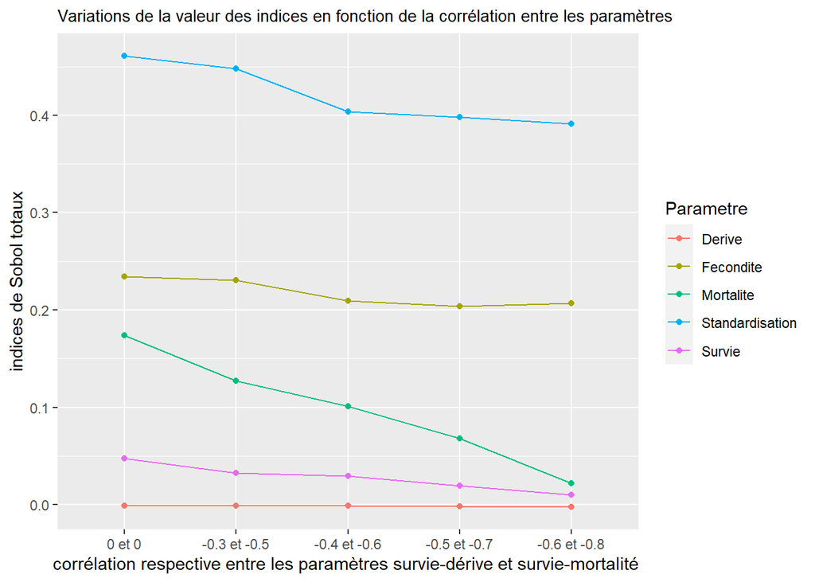

##### 5.2.3.1.3 année 3

Les indices des paramètres non corrélés ont tendance à stagner tandis que ceux de paramètres corrélés diminuent lorsque la corrélation augmente. Le classement des paramètres ne change pas en fonction des valeurs de corrélation.

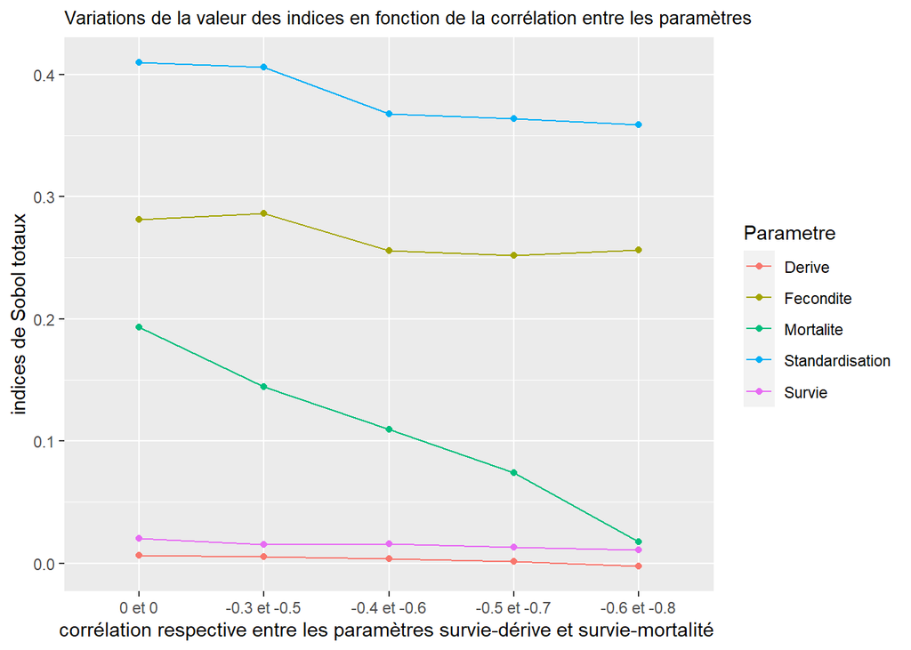

##### 5.2.3.1.4 année 4

Les indices des paramètres non corrélés ont tendance à stagner tandis que ceux de paramètres corrélés diminuent lorsque la corrélation augmente. Le classement des paramètres change à partir d’une certaines corrélation.

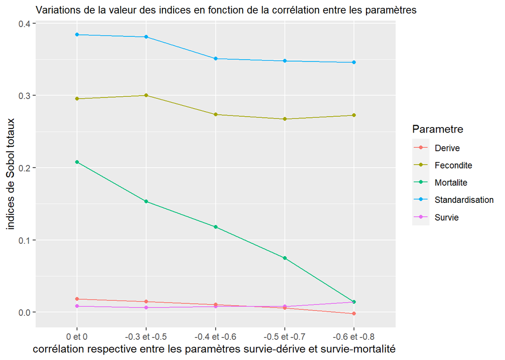

#### 5.2.3.2 biomasse féconde

##### 5.2.3.2.1 année 1

On remarque que l’augmentation de la corrélation fait diminuer l’indice du paramètre mortalité qui est un paramètre corrélé. On remarque pas l’effet de l’augmentation de la corrélation car les indices des autres paramètres corrélés car ils sont très faibles.

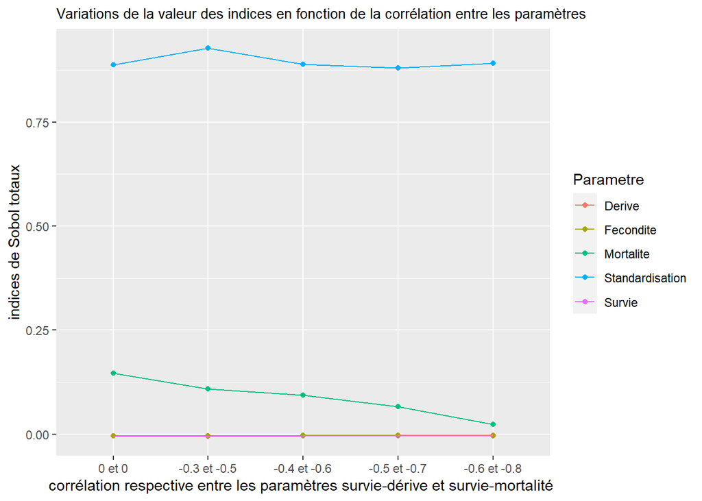

##### 5.2.3.2.2 année 2

On remarque que l’augmentation de la corrélation fait diminuer l’indice du paramètre mortalité qui est un paramètre corrélé. On remarque pas l’effet de l’augmentation de la corrélation car les indices des autres paramètres corrélés car ils sont très faibles.

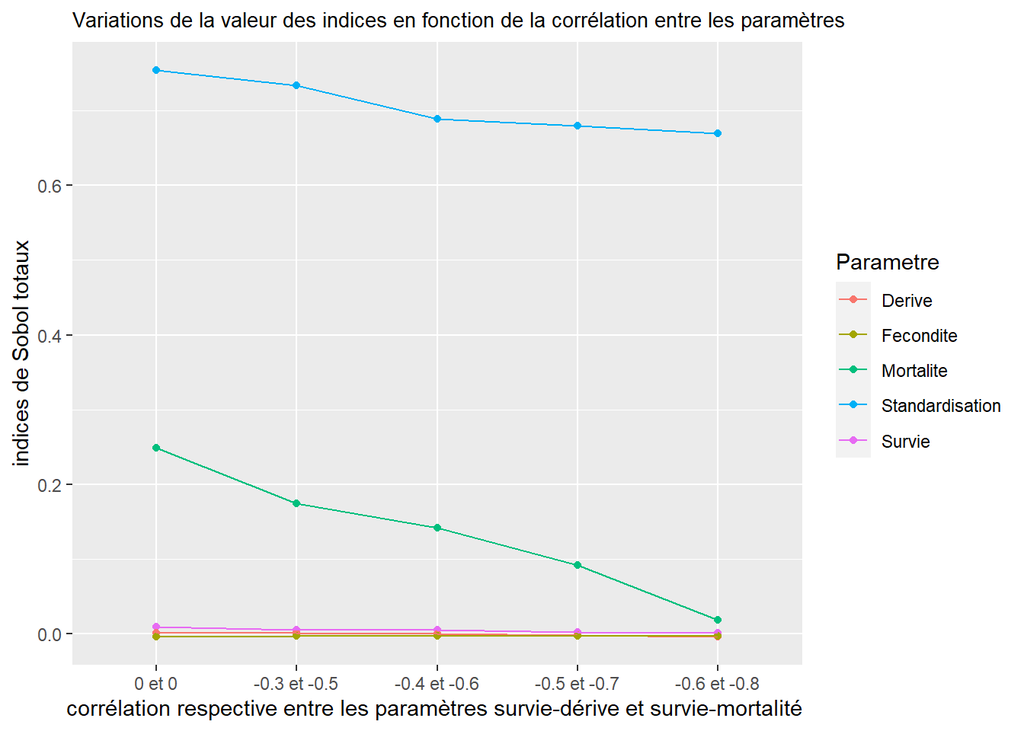

##### 5.2.3.2.3 année 3

On remarque que l’augmentation de la corrélation fait diminuer l’indice du paramètre mortalité qui est un paramètre corrélé. On remarque pas l’effet de l’augmentation de la corrélation car les indices des autres paramètres corrélés car ils sont très faibles.

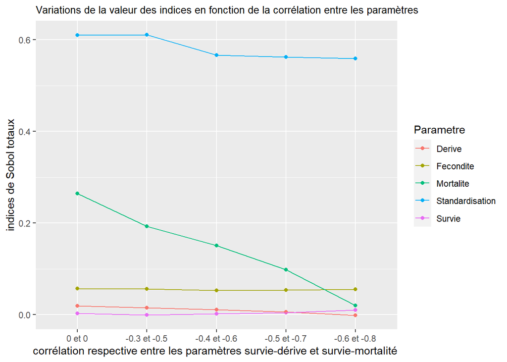

##### 5.2.3.2.4 année 4

A partir d’une certaine corrélation (-0.5 et -0.7) la mortalité (paramètre corrélé) dont l’indice diminue fortement devient moins influente que la fécondité (paramètre non corrélé) dont l’indice a stagné.

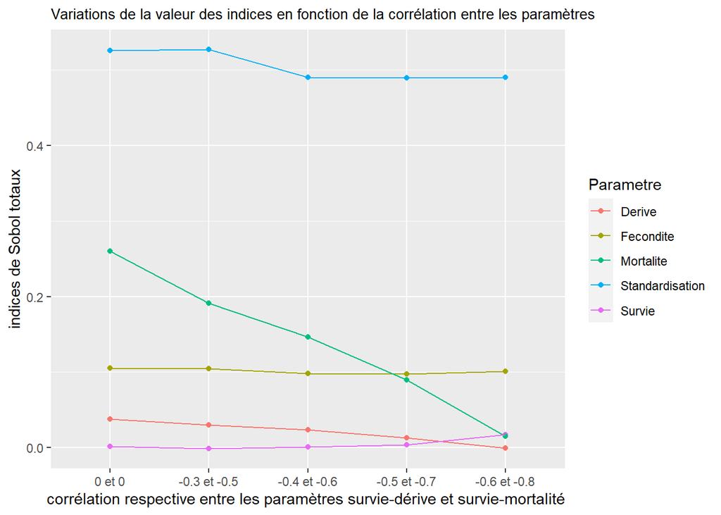

#### 5.2.3.3 captures de pêche

##### 5.2.3.3.1 année 1

Les paramètres sur lesquels on a mis une corrélation sont très influents pour corrélation faible ou nulle(surtout la survie). Ainsi la dimintion de leur importance lorsque la corrélation augmente est flagrante. De 1ère au classement par ordre d’infleunce,la survie est passée avant dernière avec l’augmentation de la corrélation.

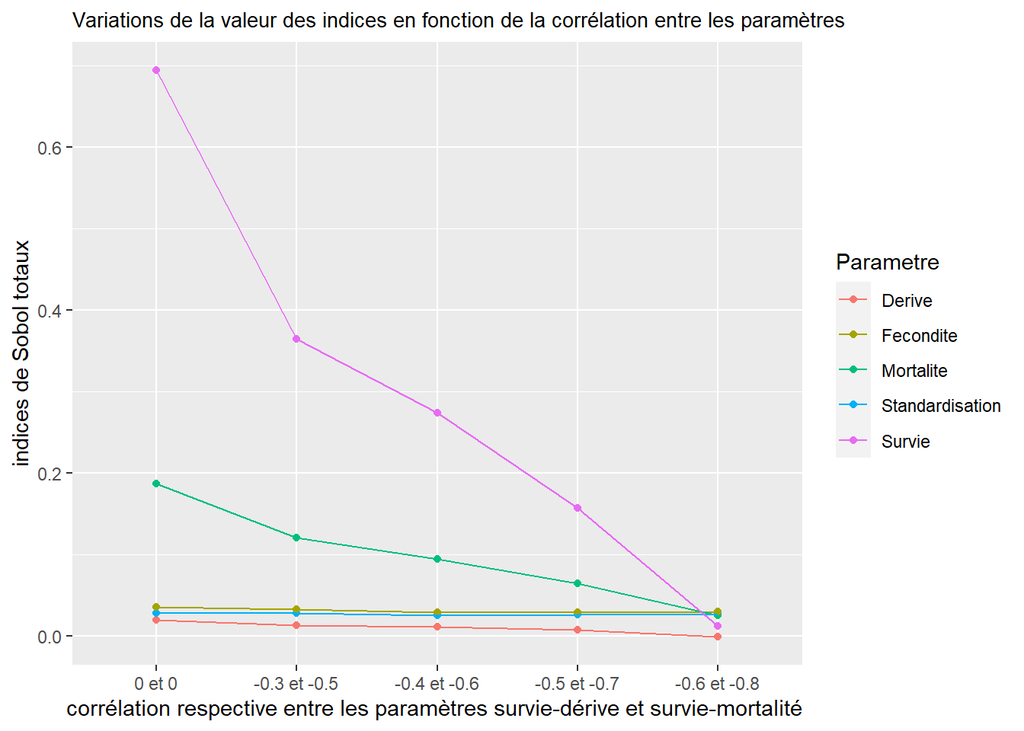

##### 5.2.3.3.2 année 2

Les paramètres sur lesquels on a mis une corrélation sont très influents pour corrélation faible ou nulle (surtout la survie et la mortalité). On voit leur valeur chuté lorsque la corrélation augmente, ce qui modifie le classement.

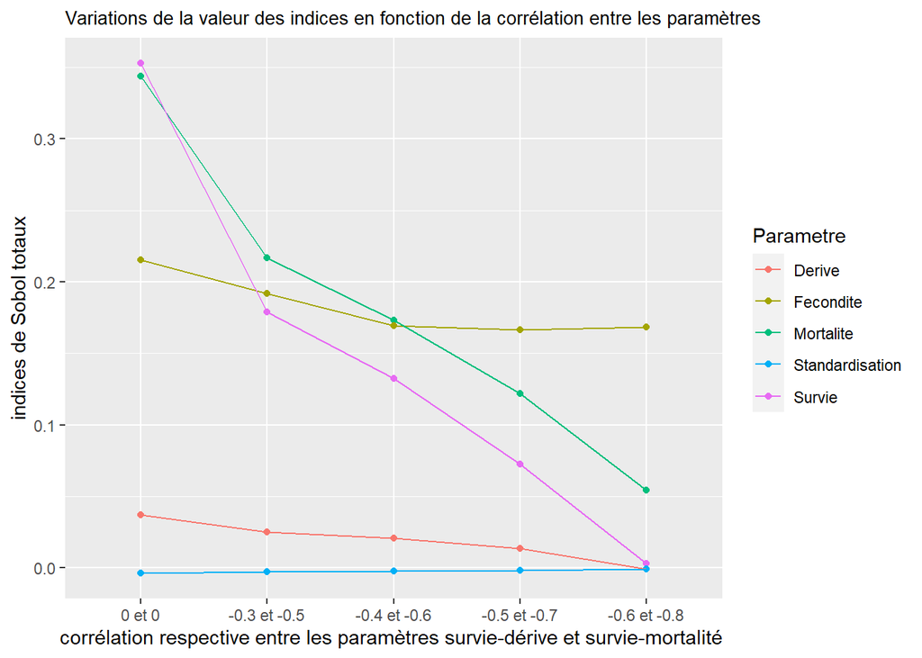

##### 5.2.3.3.3 année 3

Les paramètres sur lesquels on a mis une corrélation sont très influents pour corrélation faible ou nulle (surtout la survie et la mortalité). On voit leur valeur chuté lorsque la corrélation augmente, ce qui modifie le classement.

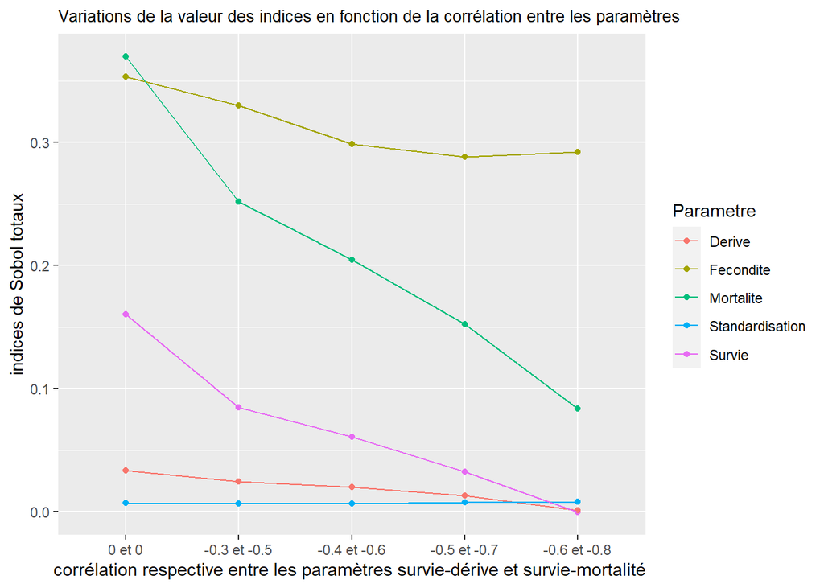

##### 5.2.3.3.4 année 4

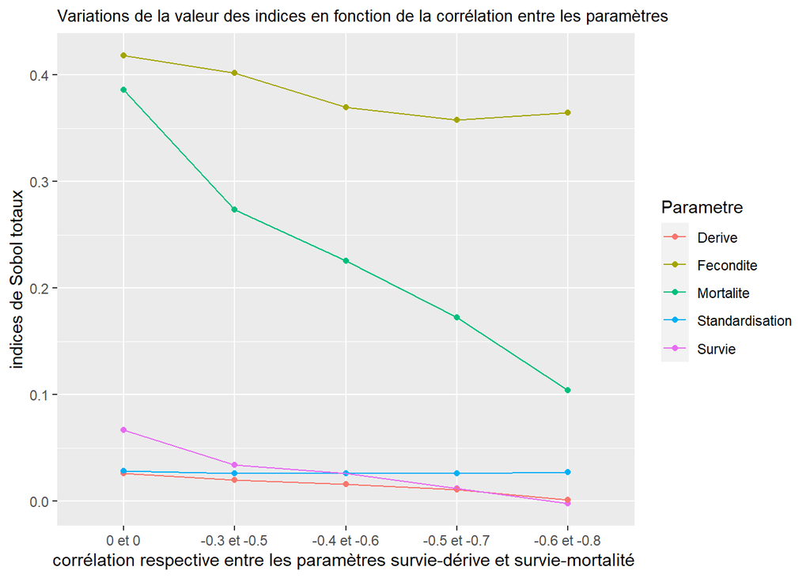

# 6 Conclusion et discussion

Au cours de cette étude, nous avons pu déterminer le classement des paramètres par ordre d’influence sur la sortie pour chaque année et pour chaque sortie du modèle (biomasse, biomasse de géniteurs et captures de pêche) lorsqu’une hyptothèse de dépendance sur les paramètres a été mise. Ainsi, cela peut nous mettre d’interpréter le mécanisme de prédiction du modèle mais aussi de choisir les entrées à fixer pour diminuer le nombres de paramètres en entrée en perdant le moins possible en précision. On remarque ensuite que le classement des paramètres change en fonction de la sortie étudiée. De plus, il évolue en fonction des années. Pour évaluer l’erreur que l’on aurait pu faire en ne prenant pas en compte la dépendance entre les paramètres, nous avons aussi calculé les indices de sensibilité pour des données dont les paramètres d’entrée sont indépendants. Nous avons remarqué des différences dans les valeurs des indices, surtout pour les paramètres sur lesquels la dépendance a été mise. Néanmoins, dans la plupart des cas, cette différence n’était pas assez grande pour changer le classement par ordre d’influence des paramètres. On en déduit donc que l’on aurait eu des résultats assez similaires sans prendre en compte la dépendance. Finalement, nous avons montré qu’une augmentation de la corrélation entre les paramètres peut changer le classement par ordre d’influence des paramètres. La valeur des indices de Sobol MDA des paramètres corrélés diminue significativement lorsque la corrélation augmente. Comme le Sobol-MDA mesure l’augmentation de l’erreur du random forest lorsque l’un des paramètres est retiré du processus de prédiction, il est normal que l’indice de Sobol total d’un paramètre fortement corrélé à un autre diminue puisque l’information qu’il apportait est contenue dans un autre paramètre. Dans une configuration à forte corrélation, il faut néanmoins rester prudent si l’on souhaite faire du factor fixing basée sur une sélection des paramètres à faible indice de sensibilité. En effet, si l’on a 3 paramètres très corrélés par exemple, leurs indices de sensibilité mesurés avec une méthode prenant en compte la dépendance sont très petits. On peut alors être tenté de fixer ces 3 paramètres mais on perdra alors beaucoup plus en précision que la somme des trois indices car il n’en resterait aucun résumant l’information contenue dans les trois. Pour éviter cela, il faut n’en fixer que deux et en garder un permettant d’apporter presque autant d’information que les 3 (grâce à leur corrélation).

Pour approfondir davantage l’étude, nous aurions pu comparer les indices obtenus à l’aide de la méthode de Sobol-MDA avec les effets de Shapley, qui prennent également en compte la dépendance, afin d’observer les différences et de déterminer si le classement reste le même. Par ailleurs, il aurait été intéressant de calculer les intervalles de confiance des indices de Sobol-MDA en fonction de l’ajustement du random forest à notre modèle. Réaliser des simulations sur une période plus étendue, telle que 10 ans ou 20 ans, aurait également pu être bénéfique, car les prévisions à long terme du modèle peuvent être utilisée pour l’aide à prise de décisions. Dans une perspective différente, l’exploration et l’utilisation des métamodèles obtenus pourraient également être envisagées.

# 7 Annexe

## 7.1 Indices de Sobol

Les indices de Sobol (Da Veiga et al. (2021)) sont des indices de sensibilité obtenus grâce à une méthode de décomposition de la variance fonctionnelle. Il sont compris entre 0 et 1 et leur somme vaut 1. Il représentent le pourcentage de la variance de la réponse expliquée par la variable (ou le groupe de variables) pour laquelle ils sont calculés. Voyons cela plus en détails.

On note dans la suite X le vecteur incluant l’ensemble des variables d’entrée incertaines : $X = (X_1 ,...., X_K)$, où K est le nombre de facteurs incertains. On note finalement G(X) le vecteur des variables de sortie du modèle associées à X. Si le modèle ne comporte qu’une seule variable de sortie ou si on ne s’intéresse qu’à une seule des variables de sortie du modèle, G(X) est un scalaire.

On va maintenant chercher à décomposer des fonctions de $L^2(P_X)$ sur des sous-espace de facteurs appropriés.

Soit $G \in L^2(P_X)$. Sous l’hypothèse 1, il existe une décomposition unique de $G$ dans $L^2(P_X)$ de la forme

$$G(x) = \sum_{A \in P_d} G_A(x_A)$$

telle que les deux propriétés suivantes soient satisfaites :

1. $G_\emptyset$ est constant.
2. $\forall A \in P_d, A \neq \emptyset, \forall i \in A, \int_{E_i} G_A(x_A) \, P_{X_i}(dx_i) = 0$

La solution unique s’exprime, $\forall A \in P_{d},$

$$G_A(x_A) = \sum_{B \subseteq A} (-1)^{|A| - |B|} \mathbb{E}[G(X) \,|\,
X_B = x_B]$$

Pour tout $A \in P_d, A \neq \emptyset$, posons $V_A = \text{Var } G_A(X_A)$. Alors, sous l’hypothèse 1, nous obtenons
$$V = \text{Var } G(X) = \sum_{A \in P_d, A \neq \emptyset} V_A.$$
De plus, pour tout $A \in P_d, A \neq \emptyset$, on :
$$V_A = \sum_{B \subset A} (-1)^{|A| - |B|} \text{Var }
\mathbb{E}[G(X)|X_B]$$
On peut démontrer que $G_A$ est la meilleure approximation de $G$ dans le sens de $L^2(P_X)$, appartenant à $L^2_A$ et étant orthogonal (par rapport au produit scalaire hilbertien dans $L^2(P_X)$) à toute fonction dans $L^2_{A_0}, A_0 \subsetneq A$.

Maintenant que nous avons défini le cadre théorique sur lequel repose la définition des indices de Sobol, voyons leur expression mathématique.

Soit $G \in L^2(P_X)$ et on suppose que l’hypothèse 1 est satisfaite. Soit $A \in P_d$.

- L’indice de Sobol associé à A est défini tel que :
  $$S_A = \frac{V_A}{V} = \frac{\sum_{B \subseteq A} (-1)^{|A| - |B|}
  \text{Var} \left[E[G(X) | X_B]\right]}{\text{Var} [G(X)]}.$$
- $S_j$ est l’indice de Sobol associé au singleton $\{j\}$. On l’appelle l’indice d’ordre un pour la variable d’entrée $X_j$. Plus généralement, si $p = |A|$, alors $S_A$ est appelé l’indice de Sobol d’ordre p associé à $X_A$.
- L’indice de Sobol fermé associé à l’ensemble A est défini tel que
  $$S^{\text{clos}}_A = \sum_{A'\subset
  A}S_{A'}=\frac{\text{Var} E[G(X)|X_A]}{\text{Var} G(X)}$$
  Cet indice est également appelé l’indice de Sobol du premier ordre associé au vecteur d’entrée $X_A$.
- L’indice de Sobol total associé à $X_A$ est défini tel que :
  $$S^{T}_A = 1 - S^{\text{clos}}_{A^c}.$$

Les indices de Sobol possèdent les propriétés suivantes :

Soit $G \in L^2(P_X)$. Supposons que l’hypothèse $1$ est satisfaite. Nous avons :

1. $$\sum_{A \in P_d} S_A = 1.$$
2. Si $\sum_{j=1}^d S_j = 1$, alors le modèle est additif (c’est-à-dire que $G$ est simplement la somme de fonctions impliquant seulement une variable).
3. $$S_{A}^T = \frac{E [ Var (G(X)|X_{\bar{A}}) ]}{Var G(X)} =\sum_{A'
   \in P^d, A' \cap A \neq \emptyset} S_{A'}\tag{3}$$

Pour $A = \{j\}$, la dernière égalité devient $S_j = \sum_{A' \in P^d, j \in A'} S_{A'}$.

Remarque : La première égalité dans l’équation (3) est toujours vraie même pour les composantes dépendantes de $X$. Ce n’est plus le cas pour la deuxième.

## 7.2 Effets de Shapley

### 7.2.1 Contexte et prérequis

Les effets de Shapley permettent d’attribuer la valeur créée par une équipe à ses membres (Zaccour et al. (1988)). Appliqués à l’analyse de sensibilité, on peut considérer que les variables d’entrée $(X_1, ..., X_d)$ représentent les membres de l’équipe et que la valeur de la sortie Y=G(X) représente la valeur créée par l’équipe. On suppose que $G(X) \in L^2(P_X)$ où $P_X$ est la loi de probabilité de X. Les effets de Shapley résultent d’une allocation directe d’une part de la variance de la sortie à chaque entrée(Da Veiga et al. (2021)). Voyons cela plus en détails.

Considérons une fonction charactéristique val définie sur $P_d$ ($P_d = P([1 : d])$, l’ensemble de tous les sous-ensembles de [1 : d] = {1, . . . , d}) et à valeurs dans $\mathbb{R}_+$ telle que $val(\emptyset)=0$. Basée sur cette fonction charactéristique, une valeur $\Phi_j$ est attribuée à chaque variable d’entrée $X_j$ (à chaque joueur dans le contexte de la théorie des jeux). La méthode d’attribution des valeurs $\Phi_j$ aux covariables doit vérifier les 4 propriétés suivantes :

- efficacité : $\sum_{j=1}^{d} \phi_j = \text{val}([1 : d])$. Cette propriété traduit le fait que les ressources disponibles pour la coalition des variables sont réparties entre elles.
- symétrie : Si $\text{val}(A \cup \{i\}) = \text{val}(A \cup \{j\})$ pour tout $A \subseteq -\{i, j\}$, alors $\Phi_i = \Phi_j$. Cette propriété traduit le fait que si 2 variables d’entrée ont la même contribution marginale à toute coalition alors on leur attribue la même valeur.
- variable muette : Si $\text{val}(A \cup \{i\}) = \text{val}(A)$ pour tout $A \in \mathcal{P}_d$, alors $\phi_i = 0$. Cette propriété traduit le fait que si quelque soit l’ensemble auquel une variable appartient elle ne change pas l’effet de cet ensemble sur la sortie alors on lui attribue une valeur nulle.
- additivité : Si $val$ et $val_1$ ont respectivement des valeurs de Shapley $\Phi$ et $\Phi1$, alors le jeu avec une valeur $val + val_1$ a une valeur de Shapley $\Phi_j + \Phi1_{j}$ pour $j \in [1 : d]$. La valeur est un opérateur additif dans l’espace de tous les jeux.

L’unique valeur $\phi$ qui satisfait les 4 propriétés attribue une valeur aux variables $X_{j}$ selon la formule suivante (voir la preuve dans (Shapley (1953))) :
$$\phi_j = \frac{1}{d} \sum_{A \subset -j} \binom{d-1}{|A|}^{-1} [val(A
\cup \{j\}) - val(A)]$$

### 7.2.2 Définition

Pour tout $j = 1, \ldots, d$, on définit l’indice de Shapley pour $X_j$ comme
$$\text{Sh}_j = \frac{1}{d} \sum_{A \subset -j} \binom{d-1}{|A|}^{d-1}
\left( S^{clos}_{A \cup \{j\}} - S^{clos}_A \right)$$
Cette définition correspond à la valeur $\phi_j$ obtenue en définissant la fonction charactéristique $val : \mathcal{P}_d \rightarrow \mathbb{R}^+$ comme
$$\text{val}(A) = S^{clos}_A = \frac{\text{Var} E[G(X) | X_A]}{V} \quad
(1)$$

On peut choisir de définir la fonction charactéristique $\text{val}_0 : \mathcal{P}_d \rightarrow \mathbb{R}^+$ par $\text{val}_0(A) = \frac{E \, \text{Var}[G(X) | X_{\overline{A}}]}{V} \quad (2)$ pour obtenir les mêmes résultats. Cette fonction est utilisée dans certains algorithmes d’estimation des indices.

### 7.2.3 Propriétés

Les indices de Shapley sont compris entre 0 et 1 et on a $\sum_{j=1}^{d} \text{Sh}_j=1$.

## 7.3 Indices HSIC

Dans certains cas où la variance ne représente pas très fidèlement la variabilité de la distribution, la mesure d’importance du moment indépendant (voir Da Veiga (2021)) peut s’avérer très utile. On va alors chercher à définir la dépendance entre la sortie Y et chaque paramètre d’entrée $X_k$ d’un point de vue probabiliste. Pour cela, l’idée est de trouver une fonction d qui mesure la similarité entre la distribution de Y et celle de $Y|X_k$. Ainsi, l’impact de $X_k$ sur Y est donné par $S_{X_k}=E_{X_k}(d(Y,Y|X_k))$.

Pour mesurer la dépendance entre X et Y on peut utiliser une mesure qui compare la distribution jointe $P_{X,Y}$ et le produit des distributions marginales indépendantes $P_XP_Y$. On peut, par exemple, utiliser la mesure de la divergence maximale de la moyenne (MMD) défini comme suit :

$$MMD^2(P_{Y,X},P_XP_Y)=\sup_{f \in
\mathcal{F}} \left[ \mathbb{E}_{P_{XY}} f (x, y) - \mathbb{E}_{P_X P_Y}
f (x, y) \right]^2$$
$$=\lVert\mu_{P_{X,Y}} - \mu_{P_X
P_Y}\rVert^2_{F\times G}$$
$$=HSIC(X,Y)$$

On peut de plus montrer que cette mesure est égale au critère d’indépendance de Hilbert-Schmidt (HSIC), une mesure qui dépend d’un noyau défini dans l’espace joint (voir Da Veiga (2021) pour des explications détaillées).

L’indice de sensibilité basé sur le critère Hsic est défini de la manière suivante :

$$S^{HSIC_{F,G}}_{X^k} = R(X^k,
Y)_{F,G}$$
où la corrélation de distance basée sur le noyau de kernel est donnée par
$$R^2(X, Y)_{F,G} =
\frac{\text{HSIC}(X, Y)_{F,G}}{\sqrt{\text{HSIC}(X, X)_{F,F}
\text{HSIC}(Y, Y)_{G,G}}}$$

Lorsque les variables d’entrée sont dépendantes, on peut utiliser l’effet de Shapley-HSIC défini comme suit :

$$Sh^{HSIC}_j =\frac{1}{HSIC(X,Y)}
\frac{1}{p} \sum_{A \subset -j} {{p-1 \choose |A|}}^{-1} (
\text{HSIC}(X_{A \cup \{j\}}, Y) - \text{HSIC}(X_A, Y) )$$

La propriété de la somme $\sum_{j=1}^{d} Sh^{HSIC}_j = 1$ reste valable.

# Bibliographie

Bénard, Clément, Sébastien Da Veiga, and Erwan Scornet. 2022. “Mean Decrease Accuracy for Random Forests: Inconsistency, and a Practical Solution via the Sobol-MDA.” *Biometrika* 109 (4): 881–900.

Breiman, Leo. 2001. “Random Forests.” *Machine Learning* 45: 5–32.

———. 2002. *Manual on Setting up, Using, and Understanding Random Forests*. *Statistics Department University of California Berkeley*. USA, CA.

———. 2017. *Classification and Regression Trees*. Routledge.

Cutler, Adele, D Richard Cutler, and John R Stevens. 2012. “Random Forests.” *Ensemble Machine Learning: Methods and Applications*, 157–75.

Da Veiga, Sébastien. 2021. “Kernel-Based ANOVA Decomposition and Shapley Effects–Application to Global Sensitivity Analysis.” *arXiv Preprint arXiv:2101.05487*.

Da Veiga, Sébastien, Fabrice Gamboa, Bertrand Iooss, and Clémentine Prieur. 2021. *Basics and Trends in Sensitivity Analysis: Theory and Practice in r*. SIAM.

Faivre, Robert, David Makowski, Stéphanie Mahévas, and Bertrand Iooss. 2013. “Analyse de Sensibilité Et Exploration de Modèles: Application Aux Sciences de La Nature Et de l’environnement.” *Analyse de Sensibilité Et Exploration de Modèles*, 1–352.

Genuer, Robin, Jean-Michel Poggi, and Christine Tuleau-Malot. 2010. “Variable Selection Using Random Forests.” *Pattern Recognition Letters* 31 (14): 2225–36.

Mahévas, Stéphanie, and Dominique Pelletier. 2004. “ISIS-Fish, a Generic and Spatially Explicit Simulation Tool for Evaluating the Impact of Management Measures on Fisheries Dynamics.” *Ecological Modelling* 171 (1-2): 65–84.

milieumarinfrance. 2008. “Directive Cadre Stratégie Pour Le Milieu Marin (DCSMM).” 2008. https://www.milieumarinfrance.fr/Nos-rubriques/Cadre-reglementaire/Directive-Cadre-strategie-pour-le-milieu-marin.

———. 2014. “Directive-Cadre Pour La Planification de l’espace Maritime (DCPEM).” 2014. https://www.milieumarinfrance.fr/Nos-rubriques/Cadre-reglementaire/Directive-Cadre-pour-la-planification-de-l-espace-maritime.

MIMI, équipe. 2022. “Mimi Partager Les Représentations, Les Connaissances Et Les Incertitudes Des Socio-Écosystèmes Marins Livret 1.” https://projet-mimi.fr/.

———. 2023. “Mimi Partager Les Représentations, Les Connaissances Et Les Incertitudes Des Socio-Écosystèmes Marins Livret 2.” https://projet-mimi.fr/.

Saltelli, Andrea, Stefano Tarantola, Francesca Campolongo, Marco Ratto, et al. 2004. *Sensitivity Analysis in Practice: A Guide to Assessing Scientific Models*. Vol. 1. Wiley Online Library.

Scornet, Erwan. 2023. “Trees, Forests, and Impurity-Based Variable Importance in Regression.” In *Annales de l’institut Henri Poincare (b) Probabilites Et Statistiques*, 59:21–52. 1. Institut Henri Poincaré.

Shapley, Lloyd S. 1953. “A Value for n-Persons Game.” In *Contributions to the Theory of Games II*, edited by Harold W. Kuhn and Albert W. Tucker, volume 28:pages 307–317. Princeton, NJ: Princeton University Press.

Williamson, Brian D, Peter B Gilbert, Noah R Simon, and Marco Carone. 2023. “A General Framework for Inference on Algorithm-Agnostic Variable Importance.” *Journal of the American Statistical Association* 118 (543): 1645–58.

Wright, Marvin N, and Andreas Ziegler. 2015. “Ranger: A Fast Implementation of Random Forests for High Dimensional Data in c++ and r.” *arXiv Preprint arXiv:1508.04409*.

Wright, Marvin N, Andreas Ziegler, and Inke R König. 2016. “Do Little Interactions Get Lost in Dark Random Forests?” *BMC Bioinformatics* 17: 1–10.

Zaccour, Georges et al. 1988. “Valeur de Shapley Et Partage équitable Des Ressources.” *L’Actualité économique* 64 (1): 96–121.